# Assignment 9: Spatial Analysis in R

Natalie von Turkovich

## OVERVIEW

This exercise accompanies the lessons in Environmental Data Analytics (ENV872L) on spatial analysis.

### Directions

1. Change “Student Name” on line 3 (above) with your name.
2. Use the lesson as a guide. It contains code that can be modified to complete the assignment.
3. Work through the steps, **creating code and output** that fulfill each instruction.
4. Be sure to **answer the questions** in this assignment document. Space for your answers is provided in this document and is indicated by the “>” character. If you need a second paragraph be sure to start the first line with “>”. You should notice that the answer is highlighted in green by RStudio.
5. When you have completed the assignment, **Knit** the text and code into a single HTML file.
6. After Knitting, please submit the completed exercise (PDF file) in Sakai. Please add your last name into the file name (e.g., “Fay_A10_SpatialAnalysis.pdf”) prior to submission.

## DATA WRANGLING

### Set up your session

1. Check your working directory
2. Import libraries: tidyverse, sf, leaflet, and mapview

```r
#1.
getwd()
```

```
## [1] "/Users/natalievonturkovich/Documents/DUKE/Courses/Spring 22/ENV_872_EDA/Environmental_Data_Analytics_2022"
```

```r
#2.
library(tidyverse)
library(lubridate)
library(leaflet)
library(sf)
```

```r
library(mapview)
library(RColorBrewer)

# Set theme
mytheme <- theme_classic(base_size = 14) +
  theme(axis.text = element_text(color = "black"),
        legend.position = "top")
theme_set(mytheme)
```

### Read (and filter) county features into an sf dataframe and plot

In this exercise, we will be exploring stream gage height data in Nebraska corresponding to floods occurring there in 2019. First, we will import from the US Counties shapefile we’ve used in lab lessons, filtering it this time for just Nebraska counties. Nebraska’s state FIPS code is `31` (as North Carolina’s was `37`).

3. Read the `cb_2018_us_county_20m.shp` shapefile into an sf dataframe, filtering records for Nebraska counties (State FIPS = 31)
4. Reveal the dataset’s coordinate reference system
5. Plot the records as a map (using `mapview` or `ggplot`)

```r
#3. Read in Counties shapefile into an sf dataframe, filtering for just NE counties
counties_sf<- st_read('./Data/Spatial/cb_2018_us_county_20m.shp') %>%
  filter(STATEFP == 31) #Filter for just NE Counties
#4. Reveal the CRS of the counties features
st_crs(counties_sf)
```

```
## Coordinate Reference System:
##   User input: NAD83
##   wkt:
## GEOGCRS["NAD83",
##     DATUM["North American Datum 1983",
##         ELLIPSOID["GRS 1980",6378137,298.257222101,
##             LENGTHUNIT["metre",1]]],
##     PRIMEM["Greenwich",0,
##         ANGLEUNIT["degree",0.0174532925199433]],
##     CS[ellipsoidal,2],
##         AXIS["latitude",north,
##             ORDER[1],
##             ANGLEUNIT["degree",0.0174532925199433]],
##         AXIS["longitude",east,
##             ORDER[2],
##             ANGLEUNIT["degree",0.0174532925199433]],
##     ID["EPSG",4269]]
```

```r
#5. Plot the data
mapView(counties_sf)
```

[interactive chart not shown]

6. What is the EPSG code of the Counties dataset? Is this a geographic or a projected coordinate reference system? (Or, does this CRS use angular or planar coordinate units?) To what datum is this CRS associated? (Tip: look the EPSG code on https://spatialreference.org)

> ANSWER:  
> The EPSG code is 4269. This is a geographic coordinate reference system, using angular units (degrees). The datum associated with this CRS is NAD North American Datum 1983.

### Read in gage locations csv as a dataframe, then display the column names it contains

Next we’ll read in some USGS/NWIS gage location data added to the `Data/Raw` folder. These are in the `NWIS_SiteInfo_NE_RAW.csv` file.(See `NWIS_SiteInfo_NE_RAW.README.txt` for more info on this dataset.)

7. Read the NWIS_SiteInfo_NE_RAW.csv file into a standard dataframe.
8. Display the column names of this dataset.

```r
#7. Read in gage locations csv as a dataframe
NWIS_SiteInfo <- read.csv("Data/Raw/NWIS_SiteInfo_NE_RAW.csv")

#8. Reveal the names of the columns
colnames(NWIS_SiteInfo)
```

```
## [1] "site_no"            "station_nm"         "site_tp_cd"
## [4] "dec_lat_va"         "dec_long_va"        "coord_acy_cd"
## [7] "dec_coord_datum_cd"
```

```r
head(NWIS_SiteInfo)
```

|  | site_no | station_nm | site_tp_cd | dec_lat_va | dec_long_va | coord_acy_cd | dec_coord_datum_cd |
| --- | --- | --- | --- | --- | --- | --- | --- |
| 1 | 6453600 | Ponca Creek at Verdel, Nebr. | ST | 42.81111 | -98.17583 | S | NAD83 |
| 2 | 6454100 | Niobrara River at Agate, Nebr. | ST | 42.42361 | -103.79222 | S | NAD83 |
| 3 | 6461500 | Niobrara River near Sparks, Nebr. | ST | 42.90222 | -100.36222 | S | NAD83 |
| 4 | 6463500 | Long Pine Creek near Riverview, Nebr. | ST | 42.68944 | -99.67889 | S | NAD83 |
| 5 | 6463720 | Niobrara River at Mariaville, Nebr. | ST | 42.78056 | -99.33972 | S | NAD83 |
| 6 | 6465500 | Niobrara River near Verdel, Nebr. | ST | 42.73972 | -98.22278 | S | NAD83 |

### Convert the dataframe to a spatial features (“sf”) dataframe

10. Convert the dataframe to an sf dataframe.
- Note: These data use the same coordinate reference system as the counties dataset
11. Display the column names of the resulting sf dataframe

```r
#10. Convert to an sf object

NWIS_SiteInfo_sf <- NWIS_SiteInfo %>%
  st_as_sf(coords = c('dec_long_va','dec_lat_va'), crs=4269) #long=x, lat = y


#11. Re-examine the column names

head(NWIS_SiteInfo_sf)
```

|  | site_no | station_nm | site_tp_cd | coord_acy_cd | dec_coord_datum_cd | geometry |
| --- | --- | --- | --- | --- | --- | --- |
| 1 | 6453600 | Ponca Creek at Verdel, Nebr. | ST | S | NAD83 |  |
| 2 | 6454100 | Niobrara River at Agate, Nebr. | ST | S | NAD83 |  |
| 3 | 6461500 | Niobrara River near Sparks, Nebr. | ST | S | NAD83 |  |
| 4 | 6463500 | Long Pine Creek near Riverview, Nebr. | ST | S | NAD83 |  |
| 5 | 6463720 | Niobrara River at Mariaville, Nebr. | ST | S | NAD83 |  |
| 6 | 6465500 | Niobrara River near Verdel, Nebr. | ST | S | NAD83 |  |

```r
#class(NWIS_SiteInfo_sf)
#st_crs(NWIS_SiteInfo_sf)
#ggplot(data=NWIS_SiteInfo_sf) +
  #geom_sf()
```

12. What new field(s) appear in the sf dataframe created? What field(s), if any, disappeared?

> ANSWER: Columns “dec_lat_va” and “dec_long_va” disappeared and column “geometry” which contains the coordinate points appeared.

### Plot the gage locations on top of the counties

13. Use `ggplot` to plot the county and gage location datasets.
- Be sure the datasets are displayed in different colors
- Title your plot “NWIS Gage Locations in Nebraska”
- Subtitle your plot with your name

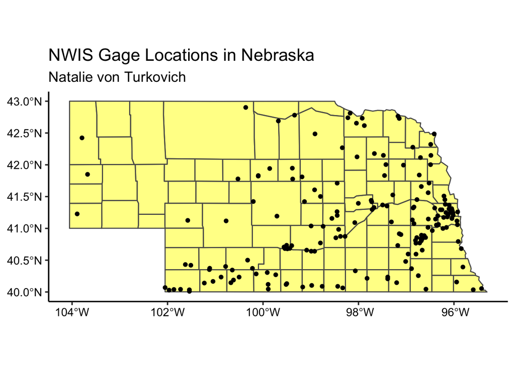

```r
#13. Plot the gage locations atop the county features         ** how to make a legend for the dots

ggplot()+
  geom_sf(data=counties_sf, fill='yellow', alpha=.5)+
  geom_sf(data=NWIS_SiteInfo_sf, fill = 'purple')+
  labs(title="NWIS Gage Locations in Nebraska", subtitle = "Natalie von Turkovich")
```

### Read in the gage height data and join the site location data to it.

Lastly, we want to attach some gage height data to our site locations. I’ve constructed a csv file listing many of the Nebraska gage sites, by station name and site number along with stream gage heights (in meters) recorded during the recent flood event. This file is titled `NWIS_SiteFlowData_NE_RAW.csv` and is found in the Data/Raw folder.

14. Read the `NWIS_SiteFlowData_NE_RAW.csv` dataset in as a dataframe.
15. Show the column names .
16. Join our site information (already imported above) to these gage height data.
- The `site_no` and `station_nm` can both/either serve as joining attributes.
- Construct this join so that the result only includes spatial features where both tables have data.
17. Show the column names in this resulting spatial features object
18. Show the dimensions of the resulting joined dataframe

```r
#14. Read the site flow data into a data frame
NWIS_Flow.df <- read.csv("Data/Raw/NWIS_SiteFlowData_NE_RAW.csv") #*factors = true?

#15. Show the column names
head(NWIS_Flow.df)
```

|  | site_no | station_nm | date | gage_ht |
| --- | --- | --- | --- | --- |
| 1 | 6453600 | Ponca Creek at Verdel, Nebr. | 2019-03-20 14:15:00 | 12.58 |
| 2 | 6453620 | Missouri River blw Ponca Creek nr Verdel, Nebr. | 2019-03-20 14:15:00 | 19.96 |
| 3 | 6461500 | Niobrara River near Sparks, Nebr. | 2019-03-20 14:15:00 | 3.61 |
| 4 | 6461500 | Niobrara River near Sparks, Nebr. | 2019-03-20 14:15:00 | 3.63 |
| 5 | 6463500 | Long Pine Creek near Riverview, Nebr. | 2019-03-13 23:45:00 | 11.38 |
| 6 | 6463720 | Niobrara River at Mariaville, Nebr. | 2019-03-20 14:45:00 | 3.75 |

```r
#16. Join location data to it
NWIS_Flow_join <-  merge(x = NWIS_SiteInfo_sf,
                           y = NWIS_Flow.df,
                           by.x = "site_no",
                           by.y = "site_no" )

NWIS_Flow_join <- NWIS_Flow_join %>%
  select(c(site_no, station_nm.x,site_tp_cd, coord_acy_cd, dec_coord_datum_cd,date,gage_ht,geometry)) %>%
  rename(station_nm=station_nm.x)

#17. Show the column names of the joined dataset
colnames(NWIS_Flow_join)
```

```
## [1] "site_no"            "station_nm"         "site_tp_cd"
## [4] "coord_acy_cd"       "dec_coord_datum_cd" "date"
## [7] "gage_ht"            "geometry"
```

```r
#18. Show the dimensions of this joined dataset
dim(NWIS_Flow_join)
```

```
## [1] 136   8
```

### Map the pattern of gage height data

Now we can examine where the flooding appears most acute by visualizing gage heights spatially. 19. Plot the gage sites on top of counties (using `mapview`, `ggplot`, or `leaflet`) * Show the magnitude of gage height by color, shape, other visualization technique.

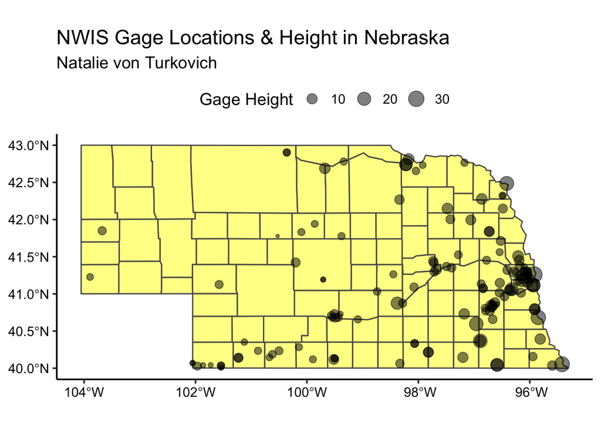

```r
#Map the points, sized by gage height  **coloring


#ggplot
ggplot()+
  geom_sf(data=counties_sf, fill='yellow', alpha=.5)+
  geom_sf(data=NWIS_Flow_join, color='black', alpha=.5, aes(size = gage_ht))+
  labs(title="NWIS Gage Locations & Height in Nebraska", subtitle = "Natalie von Turkovich", size = "Gage Height")
```

```r
#other method
mapview(counties_sf,
        zcol = "AWATER")+
mapview(NWIS_Flow_join,
        cex = "gage_ht")
```

[interactive chart not shown]

## SPATIAL ANALYSIS

Up next we will do some spatial analysis with our data. To prepare for this, we should transform our data into a projected coordinate system. We’ll choose UTM Zone 14N (EPGS = 32614).

### Transform the counties and gage site datasets to UTM Zone 14N

20. Transform the counties and gage sf datasets to UTM Zone 14N (EPGS = 32614).
21. Using `mapview` or `ggplot`, plot the data so that each can be seen as different colors

```r
#20 Transform the counties and gage location datasets to UTM Zone 14   ** CRS same as EPSG? - each seen as different colors?
#Convert all to UTM Zone 14N (EPGS = 32614)
NWIS_Flow_join_utm <- st_transform(NWIS_Flow_join, crs = 32614)
counties_sf_utm <- st_transform(counties_sf, crs = 32614)

st_crs(NWIS_Flow_join_utm)
```

```
## Coordinate Reference System:
##   User input: EPSG:32614
##   wkt:
## PROJCRS["WGS 84 / UTM zone 14N",
##     BASEGEOGCRS["WGS 84",
##         DATUM["World Geodetic System 1984",
##             ELLIPSOID["WGS 84",6378137,298.257223563,
##                 LENGTHUNIT["metre",1]]],
##         PRIMEM["Greenwich",0,
##             ANGLEUNIT["degree",0.0174532925199433]],
##         ID["EPSG",4326]],
##     CONVERSION["UTM zone 14N",
##         METHOD["Transverse Mercator",
##             ID["EPSG",9807]],
##         PARAMETER["Latitude of natural origin",0,
##             ANGLEUNIT["degree",0.0174532925199433],
##             ID["EPSG",8801]],
##         PARAMETER["Longitude of natural origin",-99,
##             ANGLEUNIT["degree",0.0174532925199433],
##             ID["EPSG",8802]],
##         PARAMETER["Scale factor at natural origin",0.9996,
##             SCALEUNIT["unity",1],
##             ID["EPSG",8805]],
##         PARAMETER["False easting",500000,
##             LENGTHUNIT["metre",1],
##             ID["EPSG",8806]],
##         PARAMETER["False northing",0,
##             LENGTHUNIT["metre",1],
##             ID["EPSG",8807]]],
##     CS[Cartesian,2],
##         AXIS["(E)",east,
##             ORDER[1],
##             LENGTHUNIT["metre",1]],
##         AXIS["(N)",north,
##             ORDER[2],
##             LENGTHUNIT["metre",1]],
##     USAGE[
##         SCOPE["Engineering survey, topographic mapping."],
##         AREA["Between 102°W and 96°W, northern hemisphere between equator and 84°N, onshore and offshore. Canada - Manitoba; Nunavut; Saskatchewan. Mexico. United States (USA)."],
##         BBOX[0,-102,84,-96]],
##     ID["EPSG",32614]]
```

```r
st_crs(counties_sf_utm)
```

```
## Coordinate Reference System:
##   User input: EPSG:32614
##   wkt:
## PROJCRS["WGS 84 / UTM zone 14N",
##     BASEGEOGCRS["WGS 84",
##         DATUM["World Geodetic System 1984",
##             ELLIPSOID["WGS 84",6378137,298.257223563,
##                 LENGTHUNIT["metre",1]]],
##         PRIMEM["Greenwich",0,
##             ANGLEUNIT["degree",0.0174532925199433]],
##         ID["EPSG",4326]],
##     CONVERSION["UTM zone 14N",
##         METHOD["Transverse Mercator",
##             ID["EPSG",9807]],
##         PARAMETER["Latitude of natural origin",0,
##             ANGLEUNIT["degree",0.0174532925199433],
##             ID["EPSG",8801]],
##         PARAMETER["Longitude of natural origin",-99,
##             ANGLEUNIT["degree",0.0174532925199433],
##             ID["EPSG",8802]],
##         PARAMETER["Scale factor at natural origin",0.9996,
##             SCALEUNIT["unity",1],
##             ID["EPSG",8805]],
##         PARAMETER["False easting",500000,
##             LENGTHUNIT["metre",1],
##             ID["EPSG",8806]],
##         PARAMETER["False northing",0,
##             LENGTHUNIT["metre",1],
##             ID["EPSG",8807]]],
##     CS[Cartesian,2],
##         AXIS["(E)",east,
##             ORDER[1],
##             LENGTHUNIT["metre",1]],
##         AXIS["(N)",north,
##             ORDER[2],
##             LENGTHUNIT["metre",1]],
##     USAGE[
##         SCOPE["Engineering survey, topographic mapping."],
##         AREA["Between 102°W and 96°W, northern hemisphere between equator and 84°N, onshore and offshore. Canada - Manitoba; Nunavut; Saskatchewan. Mexico. United States (USA)."],
##         BBOX[0,-102,84,-96]],
##     ID["EPSG",32614]]
```

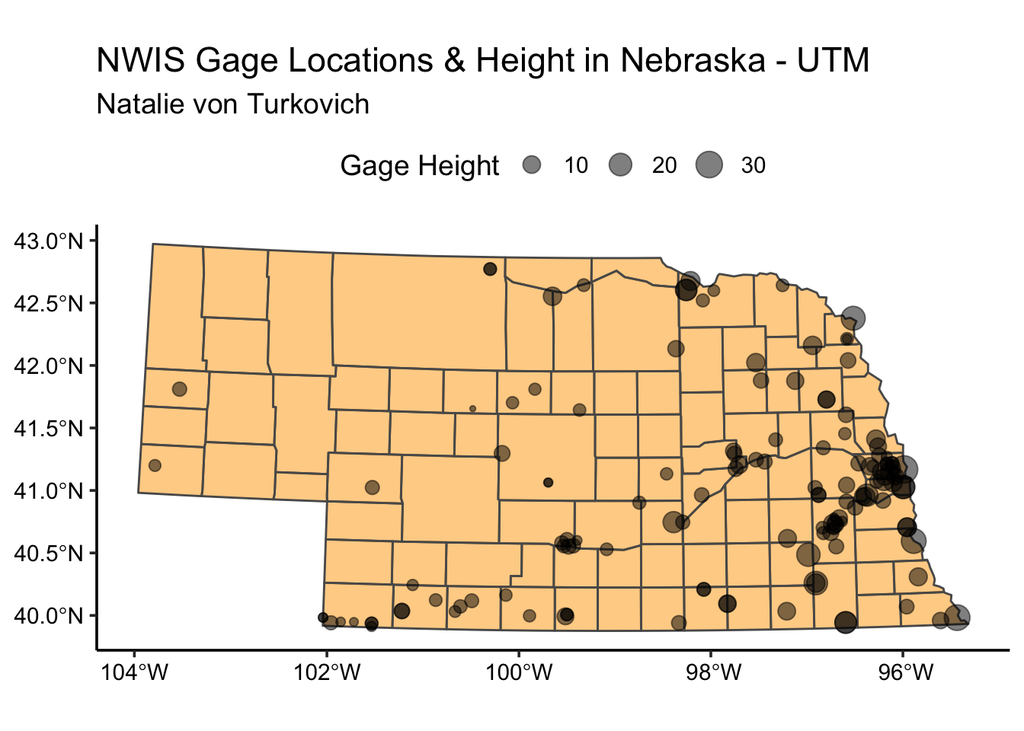

```r
#21 Plot the data
ggplot()+
  geom_sf(data=counties_sf_utm, fill='orange', alpha=.5)+
  geom_sf(data=NWIS_Flow_join_utm, color='black', alpha=.5, aes(size = gage_ht))+
  labs(title="NWIS Gage Locations & Height in Nebraska - UTM", subtitle = "Natalie von Turkovich", size = "Gage Height")
```

### Select the gages falling within a given county

Now let’s zoom into a particular county and examine the gages located there. 22. Select Lancaster county from your county sf dataframe 23. Select the gage sites falling `within` that county * Use either matrix subsetting or tidy filtering 24. Create a plot showing: * all Nebraska counties, * the selected county, * and the gage sites in that county

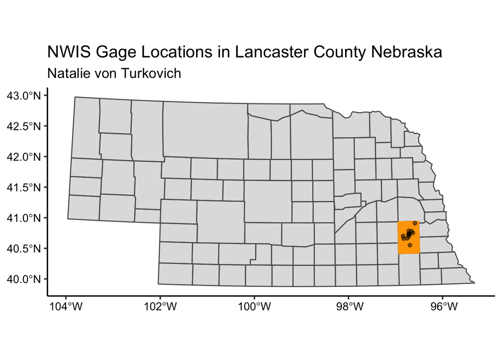

```r
#22 Select the county
Lancaster_co<-counties_sf_utm %>%
  filter(NAME %in% c('Lancaster'))

#23 Select gages within the selected county
gage_locations<-NWIS_Flow_join_utm %>%
  filter(st_within(x=., y=Lancaster_co, sparse = F))

#gage_locations<-NWIS_Flow_join_utm[Lancaster_co]

#24 Plot

ggplot()+
  geom_sf(data=counties_sf_utm, fill='grey', alpha=.5)+
   geom_sf(data = Lancaster_co, color='orange', fill = 'orange', alpha=1)+
  geom_sf(data=gage_locations, color='black', alpha=.5)+
  labs(title="NWIS Gage Locations in Lancaster County Nebraska", subtitle = "Natalie von Turkovich")
```

```r
mapview(list(counties_sf_utm, Lancaster_co, gage_locations),
        layer.name = c("Nebraska Counties", "Lancasater County", "NWIS Gage Locations"))  #how to change the color of layers
```

[interactive chart not shown]

```r
mapview(counties_sf_utm, col.reions = 'grey', name = "Nebraska Counties")+
  mapview(Lancaster_co, col.regions = 'blue',  name = "Lancasater County")+
  mapview(gage_locations, col.regions = 'red', name = "NWIS Gage Locations")
```

[interactive chart not shown]